# 20250801_abner_emmeans.Rmd

2025-08-01

```r
# First, fit your model and store it
model <- glm.nb(
    is.referenced.by.count ~ da_factor + log(age.in.months) + container.title +
        container.title*da_factor + log(age.in.months)*da_factor +
        container.title*log(age.in.months) +
        log(age.in.months) * da_factor * container.title,
    data = my_data,
    link = "log"
)
# Define the age values you want to examine (in months)
age_values <- c(12, 36, 60, 120)  # Adjust these as needed
# Get emmeans on the link scale for all combinations
emm <- emmeans(model,  ~ da_factor + age.in.months | container.title,
        at = list(age.in.months = age_values), CIs = TRUE,
        type = "response")
# Get pairwise comparisons (differences) between da_factor levels
differences <- contrast(
    emm, by = c("age.in.months", "container.title"),
    method = "pairwise",
    ratios = TRUE, CIs = TRUE
)
# See the contrasts
summary(differences)
```

```
## age.in.months = 12, container.title = Antimicrobial Agents and Chemotherapy:
##  contrast  ratio     SE  df null z.ratio p.value
##  No / Yes  1.813 0.2050 Inf    1   5.265  <.0001
##
## age.in.months = 36, container.title = Antimicrobial Agents and Chemotherapy:
##  contrast  ratio     SE  df null z.ratio p.value
##  No / Yes  1.211 0.0755 Inf    1   3.069  0.0021
##
## age.in.months = 60, container.title = Antimicrobial Agents and Chemotherapy:
##  contrast  ratio     SE  df null z.ratio p.value
##  No / Yes  1.004 0.0451 Inf    1   0.081  0.9355
##
## age.in.months = 120, container.title = Antimicrobial Agents and Chemotherapy:
##  contrast  ratio     SE  df null z.ratio p.value
##  No / Yes  0.778 0.0330 Inf    1  -5.925  <.0001
##
## age.in.months = 12, container.title = Applied and Environmental Microbiology:
##  contrast  ratio     SE  df null z.ratio p.value
##  No / Yes  1.159 0.0797 Inf    1   2.150  0.0316
##
## age.in.months = 36, container.title = Applied and Environmental Microbiology:
##  contrast  ratio     SE  df null z.ratio p.value
##  No / Yes  0.933 0.0375 Inf    1  -1.727  0.0842
##
## age.in.months = 60, container.title = Applied and Environmental Microbiology:
##  contrast  ratio     SE  df null z.ratio p.value
##  No / Yes  0.843 0.0247 Inf    1  -5.826  <.0001
##
## age.in.months = 120, container.title = Applied and Environmental Microbiology:
##  contrast  ratio     SE  df null z.ratio p.value
##  No / Yes  0.735 0.0168 Inf    1 -13.440  <.0001
##
## age.in.months = 12, container.title = Genome Announcements:
##  contrast  ratio     SE  df null z.ratio p.value
##  No / Yes  0.888 0.6270 Inf    1  -0.169  0.8662
##
## age.in.months = 36, container.title = Genome Announcements:
##  contrast  ratio     SE  df null z.ratio p.value
##  No / Yes  0.912 0.3350 Inf    1  -0.251  0.8020
##
```

[output cut: 154 more lines]

```
##  No / Yes  1.124 0.1690 Inf    1   0.773  0.4394
##
## age.in.months = 36, container.title = mSystems:
##  contrast  ratio     SE  df null z.ratio p.value
##  No / Yes  0.897 0.0686 Inf    1  -1.424  0.1546
##
## age.in.months = 60, container.title = mSystems:
##  contrast  ratio     SE  df null z.ratio p.value
##  No / Yes  0.807 0.0708 Inf    1  -2.439  0.0147
##
## age.in.months = 120, container.title = mSystems:
##  contrast  ratio     SE  df null z.ratio p.value
##  No / Yes  0.700 0.0990 Inf    1  -2.519  0.0118
##
## Tests are performed on the log scale
```

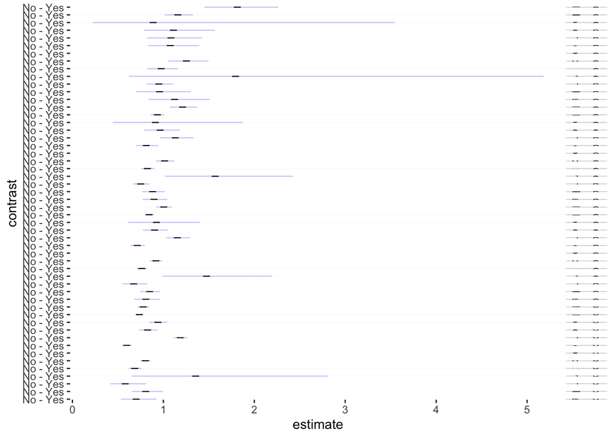

```r
# Plot the contrasts
plot(differences, ratios = TRUE)
```

```
## NOTE: Results may be misleading due to involvement in interactions
```

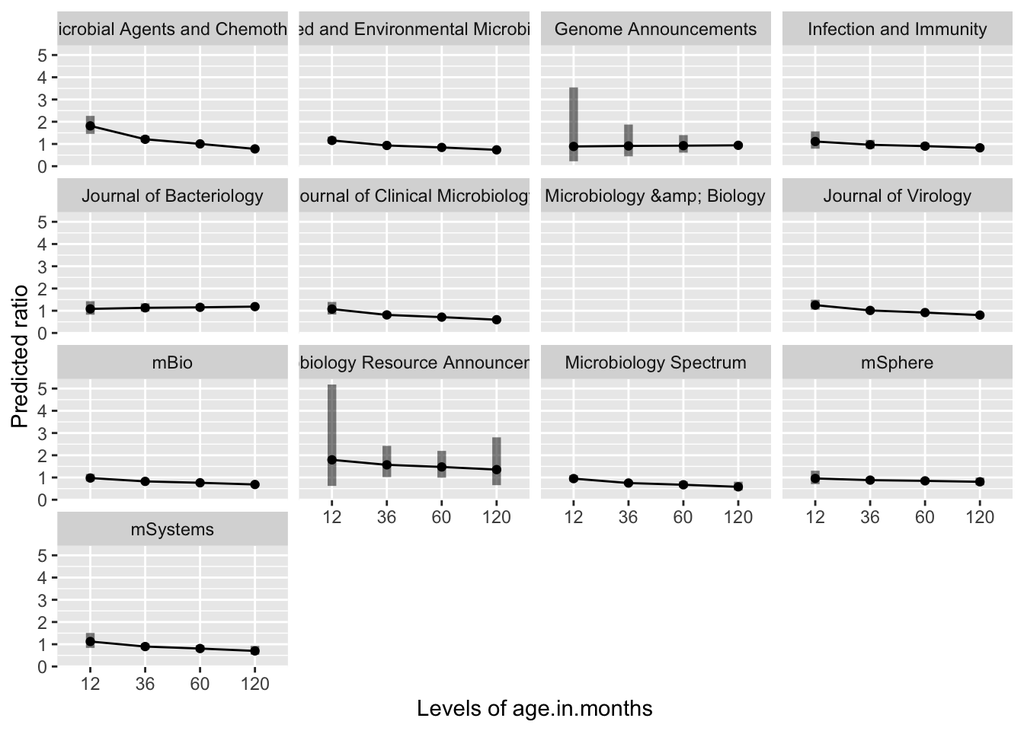

```r
# # working on plotting better
# emmip(model, ~ age.in.months | container.title, CIs = TRUE, type = "response",  at = list(age.in.months = age_values)) +
#     geom_point(aes(x = age.in.months, y = is.referenced.by.count), data = my_data, size = 1, color = "lightblue2", aes = 0.25 )

emmip(differences, ~ age.in.months | container.title, CIs = TRUE, engine = "ggplot")
```

## The Other Plot from Abner

- Also, I think this result would be even clearer if you made a plot with “age” in the horizontal axis, “predicted citations” in the vertical axis, and lines colored by “da_factor”.

```r
library(DHARMa)
```

```r
library(sjPlot)
#smaller model with 2 terms
two_term_glmnb <-function(model_data, model_name) {

  total_model <-MASS::glm.nb(is.referenced.by.count~ da_factor + log(age.in.months) +
       + log(age.in.months)*da_factor + log(age.in.months)*da_factor, data = model_data, link = log)

  return(total_model)

}

journals <-
  nsd_yes_metadata %>%
  count(journal_abrev) %>%
  filter(journal_abrev != "jmbe")

j <- 8 #mbio


  journal_data <-
  nsd_yes_metadata %>%
    filter(journal_abrev == journals[[j,1]]) %>%
    mutate(da_factor = factor(da))


  model <- two_term_glmnb(journal_data, journals[[j,1]])
summary(model)
```

```
##
## Call:
## MASS::glm.nb(formula = is.referenced.by.count ~ da_factor + log(age.in.months) +
##     +log(age.in.months) * da_factor + log(age.in.months) * da_factor,
##     data = model_data, link = log, init.theta = 1.597744281)
##
## Coefficients:
##                                 Estimate Std. Error z value Pr(>|z|)
## (Intercept)                     -2.81124    0.15592 -18.030  < 2e-16 ***
## da_factorYes                    -0.35970    0.20003  -1.798  0.07215 .
## log(age.in.months)               1.51608    0.03718  40.781  < 2e-16 ***
## da_factorYes:log(age.in.months)  0.15390    0.04860   3.166  0.00154 **
## ---
## Signif. codes:  0 '***' 0.001 '**' 0.01 '*' 0.05 '.' 0.1 ' ' 1
##
## (Dispersion parameter for Negative Binomial(1.5977) family taken to be 1)
##
##     Null deviance: 6961.8  on 2437  degrees of freedom
## Residual deviance: 2603.7  on 2434  degrees of freedom
##   (60 observations deleted due to missingness)
## AIC: 20128
##
## Number of Fisher Scoring iterations: 1
##
##
##               Theta:  1.5977
##           Std. Err.:  0.0482
##
##  2 x log-likelihood:  -20118.0870
```

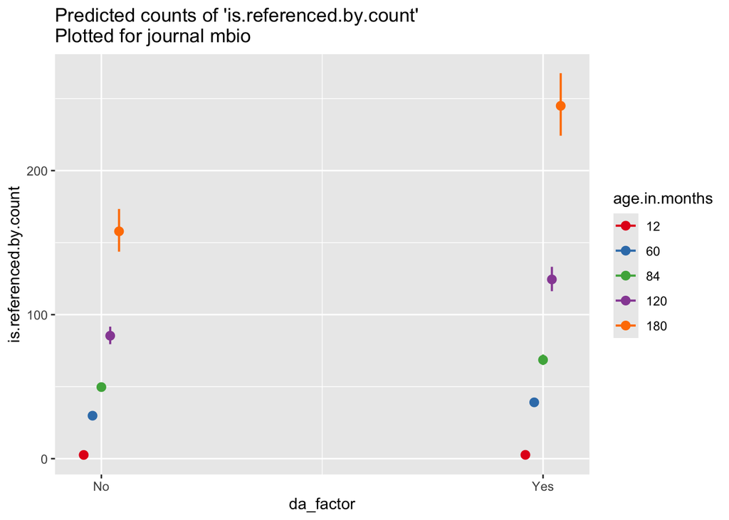

```r
  plot_model <- plot_model(model, type = "pred", terms = c("da_factor", "age.in.months[12,60,84,120,180]")) +     ggtitle(paste0("Predicted counts of 'is.referenced.by.count' \nPlotted for journal ", journals[[j,1]]))

 print(plot_model)
```

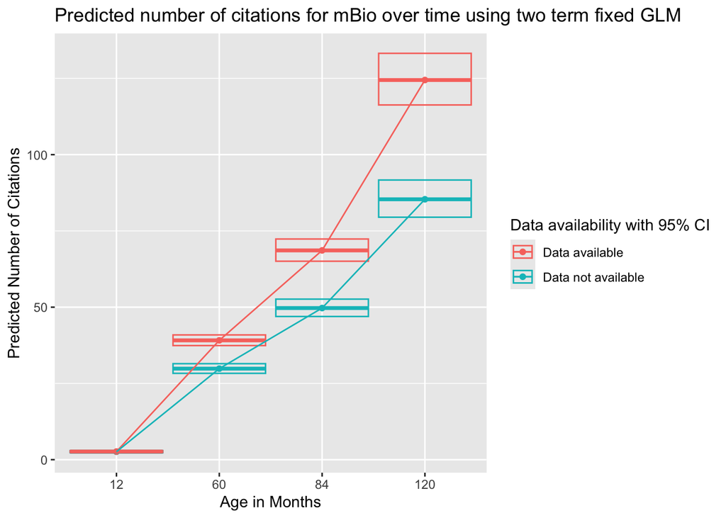

```r
 model_data <- get_model_data(model, type = "pred", terms = c("da_factor", "age.in.months[12,60,84,120]")) %>%
   tibble(da_factor = ifelse(.$x == 1, "Data not available", "Data available"), predicted_citations = .$predicted, age.in.months = .$group)



 ggplot(data = model_data, aes(x = age.in.months, y = predicted_citations,
                                color = da_factor)) +
   geom_point() +
   geom_crossbar(aes(ymin = conf.low, ymax = conf.high)) +
   geom_path(aes(x = age.in.months, y = predicted_citations, group = da_factor)) +
   labs(title = "Predicted number of citations for mBio over time using two term fixed GLM",
        x = "Age in Months",
        y = "Predicted Number of Citations",
        color = "Data availability with 95% CI")
```

# 20250801_abner_emmeans.Rmd

Published

August 1, 2025

## Protocol for all data and then data by journal

1. Fit model and store it
2. Define the age values you want to examine
   - more continuous using seq(1, 120, 4)
3. Get emmeans on the link scale for all combinations
4. Get pairwise comparisons between da factor levels (ratios)
5. Plot the contrasts using geom_ribbon
6. Create the Marginal Predictive Checks
   - These should resemble the observed outcome

[figure not shown]

[figure not shown]

## 20250818

- Do we like these figures?
- Additional changes to make?

### Create Newer Plots from Abner (20250813)

- ” Use more different values for age in months and treat them as numbers instead of factors so you can make a smoother plot. This visualization would be more consistent with your model because it uses age as a continuous variable. ” - AHB

### Previously (20250801)

- “Also, I think this result would be even clearer if you made a plot with”age” in the horizontal axis, “predicted citations” in the vertical axis, and lines colored by “da_factor”.” - AHB
- These plots are each made with a different glm.nb model (one for each journal), which is why they are not combined into a faceted plot.